# Image Descriptors

**Objectives:**

- Practising with different keypoint detectors and image descriptors
- Applying image descriptors in image matching

## Importing important packages and libraries

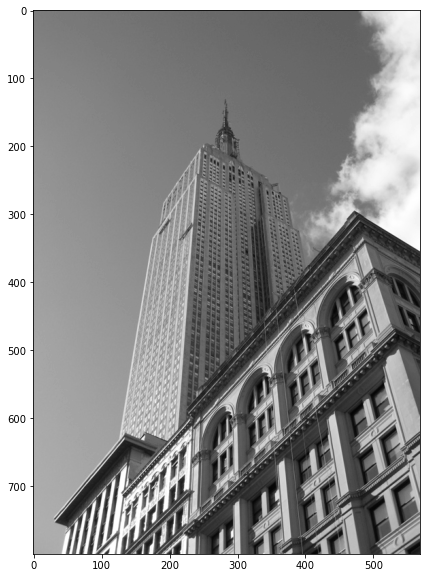

```python
import numpy as np
import cv2 as cv
from matplotlib import pyplot as plt

img = cv.imread('D:\Deakin University (Applied AI (Professional)\SIT789 (Applications of Computer Vision and Speech Processing)\Tasks & Assignments\Task-3.1P\Resources_3.1\empire.jpg') #load image
img_gray = cv.cvtColor(img, cv.COLOR_BGR2GRAY)

size = 15,10
plt.figure(figsize= size)
plt.imshow(img_gray, 'gray')
```

```python
cv.imwrite('img_gray.png', img_gray)
```

```
True
```

## Harris corner detector

```python
local_region_size = 3 #size of local image regions W
kernel_size = 3 #kernel size of Sobel kernels used for calculating derivatives I_x and I_y
k = 0.04 #parameter k
threshold = 1000.0 #threshold theta
```

```python
img_gray = np.float32(img_gray)
```

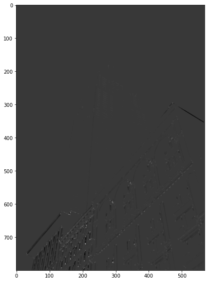

```python
Harris_res_img = cv.cornerHarris(img_gray, local_region_size, kernel_size, k)

plt.figure(figsize= size)
plt.imshow(Harris_res_img, 'gray')
```

```python
cv.imwrite('Harris_res_img.png', Harris_res_img)
```

```
True
```

### selecting and highlighting corners from Harris_res_img using our defined threshold

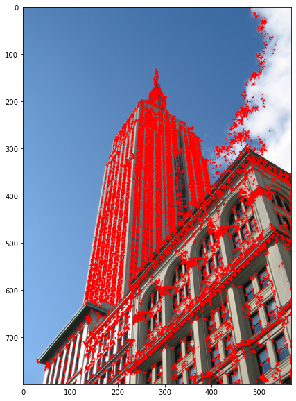

```python
highlighted_colour = [0, 0, 255] # a colour is a combination of blue, green, red; red=[0,0,255]
highlighted_img = img.copy()
highlighted_img[Harris_res_img > threshold] = highlighted_colour
plt.figure(figsize= size)
plt.imshow(highlighted_img[:,:,::-1]) # RGB-> BGR as opencv only takes BGR
```

```python
cv.imwrite('highlighted_img.png', highlighted_img)
```

```
True
```

```python
thresholdnew = 0.001 * Harris_res_img.max()
print(thresholdnew)
```

```
94003.416
```

```python
highlighted_colour = [0, 0, 255] # a colour is a combination of blue, green, red; red=[0,0,255]
highlighted_img12 = img.copy()
```

```python
height, width = img_gray.shape
for i in range(height):
    for j in range(width):
        if Harris_res_img[i, j] > thresholdnew:
            highlighted_img12[i, j] = highlighted_colour
```

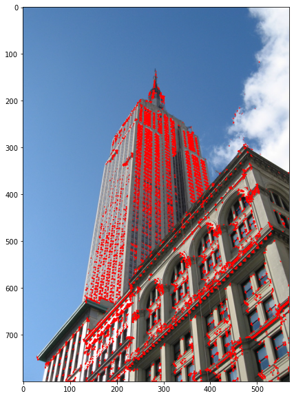

```python
Harris_res_img = cv.cornerHarris(img_gray, local_region_size, kernel_size, k)
plt.figure(figsize= size)
plt.imshow(highlighted_img12[:,:,::-1])
```

```python
cv.imwrite('highlighted_img12.png', highlighted_img12)
```

```
True
```

### Experimenting the Harris corner detector with different thresholds

```python
threshold_new_2 = 0.005 * Harris_res_img.max()
print(threshold_new_2)
```

```
470017.08
```

```python
highlighted_colour = [0, 0, 255] # a colour is a combination of blue, green, red; red=[0,0,255]
highlighted_img21 = img.copy()
```

```python
height, width = img_gray.shape
for i in range(height):
    for j in range(width):
        if Harris_res_img[i, j] > threshold_new_2:
            highlighted_img21[i, j] = highlighted_colour
```

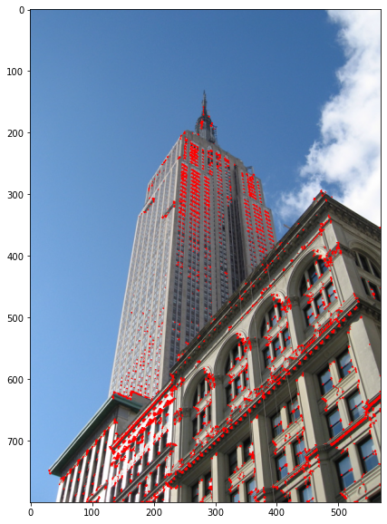

```python
Harris_res_img = cv.cornerHarris(img_gray, local_region_size, kernel_size, k)
plt.figure(figsize= size)
plt.imshow(highlighted_img21[:,:,::-1])
```

```python
cv.imwrite('highlighted_img21.png', highlighted_img21)
```

```
True
```

```python
threshold_new_3 = 0.01 * Harris_res_img.max()
print(threshold_new_3)
```

```
940034.16
```

```python
highlighted_colour = [0, 0, 255] # a colour is a combination of blue, green, red; red=[0,0,255]
highlighted_img31 = img.copy()
```

```python
height, width = img_gray.shape
for i in range(height):
    for j in range(width):
        if Harris_res_img[i, j] > threshold_new_3:
            highlighted_img31[i, j] = highlighted_colour
```

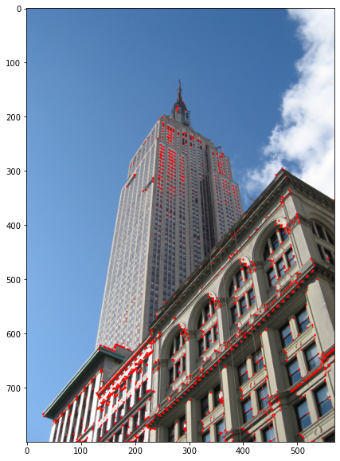

```python
Harris_res_img = cv.cornerHarris(img_gray, local_region_size, kernel_size, k)
plt.figure(figsize= size)
plt.imshow(highlighted_img31[:,:,::-1])
```

```python
cv.imwrite('highlighted_img31.png', highlighted_img31)
```

```
True
```

## SIFT

### Initialise SIFT detector

```python
sift = cv.xfeatures2d.SIFT_create()
```

### (A). Keypoint detection

**Extracting keypoints (aka interest points)**

```python
# You need re-create img_gray as its previous version have been converted to float

img_gray = cv.cvtColor(img, cv.COLOR_BGR2GRAY)

kp = sift.detect(img_gray, None)
```

### Visualising SIFT keypoints

```
Number of detected keypoints: 2804
```

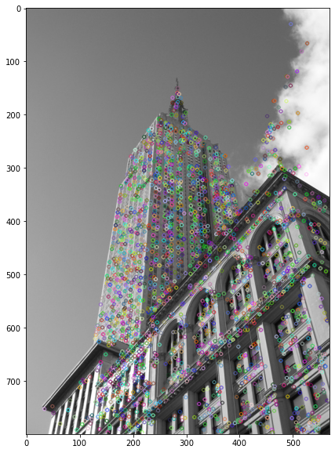

```python
img_gray_kp = img_gray.copy()
img_gray_kp = cv.drawKeypoints(img_gray, kp, img_gray_kp)

plt.figure(figsize= size)
plt.imshow(img_gray_kp)
print("Number of detected keypoints: %d" % (len(kp)))
```

```python
cv.imwrite('img_gray_kp.png', img_gray_kp)
```

```
True
```

### To visualise local image regions used for extracting SIFT descriptors

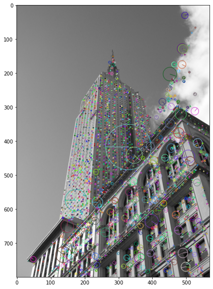

```python
img_gray_kp = cv.drawKeypoints(img_gray, kp, img_gray_kp, flags = cv.DRAW_MATCHES_FLAGS_DRAW_RICH_KEYPOINTS)

plt.figure(figsize= size)
plt.imshow(img_gray_kp)
```

```python
cv.imwrite('img_gray_kp_sift.png', img_gray_kp)
```

```
True
```

### (B). Descriptor computation

#### Based on the detected keypoints, we extract SIFT descriptors using the following commands

```python
kp, des = sift.compute(img_gray, kp)
```

```python
print(des.shape)
```

```
(2804, 128)
```

### (C). Ablation study

```python
img_45 = cv.imread('D:\Deakin University (Applied AI (Professional)\SIT789 (Applications of Computer Vision and Speech Processing)\Tasks & Assignments\Task-3.1P\Resources_3.1\empire_45.jpg')
img_zoomedout = cv.imread('D:\Deakin University (Applied AI (Professional)\SIT789 (Applications of Computer Vision and Speech Processing)\Tasks & Assignments\Task-3.1P\Resources_3.1\empire_zoomedout.jpg')
img_45_gray = cv.cvtColor(img_45, cv.COLOR_BGR2GRAY)
img_zoomedout_gray = cv.cvtColor(img_zoomedout, cv.COLOR_BGR2GRAY)
img_another = cv.imread('D:/Deakin University (Applied AI (Professional)/SIT789 (Applications of Computer Vision and Speech Processing)/Tasks & Assignments/Task-3.1P/Resources_3.1/fisherman.jpg')
img_another_gray = cv.cvtColor(img_another, cv.COLOR_BGR2GRAY)
```

### Both keypoint detection and descriptor computation can be done silmutaneously by calling "sift.detectAndCompute"

```python
kp_45, des_45 = sift.detectAndCompute(img_45_gray, None)
kp_zoomedout, des_zoomedout = sift.detectAndCompute(img_zoomedout_gray, None)
kp_another, des_another = sift.detectAndCompute(img_another_gray, None)
```

```python
print("The number of keypoints in img_gray is %d" % (len(des)))
print("The number of keypoints in img_45_gray is %d" % (len(des_45)))
```

```
The number of keypoints in img_gray is 2804
The number of keypoints in img_45_gray is 3290
```

### Computing the Hausdorff distances between: 1. des and des_45, 2. des and des_zoomedout & 3. des and des_another

```python
from scipy.spatial.distance import directed_hausdorff
```

```python
u = des
v = des_45
directed_hausdorff(u, v)[0]
```

```
399.8762308514973
```

```python
directed_hausdorff(v, u)[0]
```

```
400.4697241989711
```

The general (symmetric) Hausdorff distance between two 2-D arrays of coordinates:

```python
max(directed_hausdorff(u, v)[0], directed_hausdorff(v, u)[0])
```

```
400.4697241989711
```

Indices of the points that generate the Hausdorff distance (the Hausdorff pair):

```python
directed_hausdorff(v, u)[1:]
```

```
(2685, 2732)
```

### 2. des and des_zoomedout

```python
x = des
y = des_zoomedout
directed_hausdorff(x, y)[0]
```

```
401.33651715237676
```

```python
directed_hausdorff(y, x)[0]
```

```
398.8984833262719
```

```python
max(directed_hausdorff(x, y)[0], directed_hausdorff(y, x)[0])
```

```
401.33651715237676
```

```python
directed_hausdorff(y, x)[1:]
```

```
(862, 1056)
```

### 3. des and des_another

```python
a = des
b = des_another
directed_hausdorff(a, b)[0]
```

```
433.89630097524457
```

```python
directed_hausdorff(b, a)[0]
```

```
432.90645640831
```

```python
max(directed_hausdorff(a, b)[0], directed_hausdorff(b, a)[0])
```

```
433.89630097524457
```

```python
directed_hausdorff(b, a)[1:]
```

```
(943, 2801)
```

Using the Hausdorff distances on images between descriptors: 'des and des_45', 'des and des_zoomedout', 'des and des_another'

- We found that image 'empire' and 'empire_45' is very similar with hausdorff distance of 400.4697
- While the hausdorff distance between 'des and des_zoomedout' is very similar to 'des and des_45' with a value of 401.3365
- Even the image with totally different dimensions and pixels (des and des_another) have not that much greater hausdorff distance (value of 433.8963)
- It shows that even though we can compare the distances of the image using hausdorff distance, we still can't rely on this method as this method is not very precise and the values are very similar to each other which makes the image similarity difficult to distinguish using hausdorff distance